# Assignment_1_DATA608

## R Markdown

**Principles of Data Visualization and Introduction to ggplot2**

I have provided you with data about the 5,000 fastest growing companies in the US, as compiled by Inc. magazine. lets read this in:

```r
inc <- read.csv("https://raw.githubusercontent.com/charleyferrari/CUNY_DATA_608/master/module1/Data/inc5000_data.csv", header= TRUE)
```

And lets preview this data:

```r
head(inc)
```

```
##   Rank                         Name Growth_Rate   Revenue
## 1    1                         Fuhu      421.48 1.179e+08
## 2    2        FederalConference.com      248.31 4.960e+07
## 3    3                The HCI Group      245.45 2.550e+07
## 4    4                      Bridger      233.08 1.900e+09
## 5    5                       DataXu      213.37 8.700e+07
## 6    6 MileStone Community Builders      179.38 4.570e+07
##                       Industry Employees         City State
## 1 Consumer Products & Services       104   El Segundo    CA
## 2          Government Services        51     Dumfries    VA
## 3                       Health       132 Jacksonville    FL
## 4                       Energy        50      Addison    TX
## 5      Advertising & Marketing       220       Boston    MA
## 6                  Real Estate        63       Austin    TX
```

```r
summary(inc)
```

```
##       Rank          Name            Growth_Rate         Revenue
##  Min.   :   1   Length:5001        Min.   :  0.340   Min.   :2.000e+06
##  1st Qu.:1252   Class :character   1st Qu.:  0.770   1st Qu.:5.100e+06
##  Median :2502   Mode  :character   Median :  1.420   Median :1.090e+07
##  Mean   :2502                      Mean   :  4.612   Mean   :4.822e+07
##  3rd Qu.:3751                      3rd Qu.:  3.290   3rd Qu.:2.860e+07
##  Max.   :5000                      Max.   :421.480   Max.   :1.010e+10
##
##    Industry           Employees           City              State
##  Length:5001        Min.   :    1.0   Length:5001        Length:5001
##  Class :character   1st Qu.:   25.0   Class :character   Class :character
##  Mode  :character   Median :   53.0   Mode  :character   Mode  :character
##                     Mean   :  232.7
##                     3rd Qu.:  132.0
##                     Max.   :66803.0
##                     NA's   :12
```

Think a bit on what these summaries mean. Use the space below to add some more relevant non-visual exploratory information you think helps you understand this data:

## Solution:

The true picture emerges when we sort by standard deviation, the industries that were previously identified as having high mean and median growth rates also happen to have a high standard deviation. Taking the example of the Energy industry, it becomes clear that there is a wide gamut of companies ranging from growth rates of < 1% (Maneri~Agraz Enterprises, Customized Energy Solutions) to companies such as Bridger which have a growth rate of 233%. Looking further at the methodology behind the Inc. rankings reveals that growth rates are calculated over a 3-year timeframe and are not annualized numbers which could be the reason why the results of the aggregation below don’t align with intuition. Looking at another industry “Consumer Products & Services”, companies that are listed as having high growth rates are LivingSocial (a web rating company), Goal Zero (a portable battery company) and Fuhu (now bankrupt, previously a computer manufacturer). The growth rates for this category appear to make sense but neverthless the Inc. calculation methodology for growth rates can lead to erroneous conclusions and needs to be treated with caution.

```r
# Insert your code here, create more chunks as necessary

# Sort in descending order by median growth rates

library(tidyverse)
visualize1 <- inc %>%
  group_by(Industry) %>%
  summarise(mean_Growth_Rate = mean(Growth_Rate), median_Growth_Rate = median(Growth_Rate), sd_Growth_Rate = sd(Growth_Rate)) %>%
  arrange(desc(median_Growth_Rate))

visualize1
```

```
## # A tibble: 25 × 4
##    Industry                     mean_Growth_Rate median_Growth_R… sd_Growth_Rate
##    <chr>                                   <dbl>            <dbl>          <dbl>
##  1 Government Services                      7.24             2.11          22.1
##  2 Energy                                   9.60             2.08          25.3
##  3 Real Estate                              7.75             2.07          20.4
##  4 Media                                    4.37             1.94           5.44
##  5 Consumer Products & Services             8.78             1.82          33.9
##  6 Retail                                   6.18             1.76          16.5
##  7 Software                                 5.02             1.72          11.3
##  8 Advertising & Marketing                  6.23             1.61          17.9
##  9 Health                                   4.86             1.57          15.4
## 10 Security                                 3.39             1.54           5.80
## # … with 15 more rows
```

```r
# Sort in descending order by mean growth rates

visualize2 <- inc %>%
  group_by(Industry) %>%
  summarise(mean_Growth_Rate = mean(Growth_Rate), median_Growth_Rate = median(Growth_Rate), sd_Growth_Rate = sd(Growth_Rate)) %>%
  arrange(desc(mean_Growth_Rate))

visualize2
```

```
## # A tibble: 25 × 4
##    Industry                     mean_Growth_Rate median_Growth_R… sd_Growth_Rate
##    <chr>                                   <dbl>            <dbl>          <dbl>
##  1 Energy                                   9.60             2.08          25.3
##  2 Consumer Products & Services             8.78             1.82          33.9
##  3 Real Estate                              7.75             2.07          20.4
##  4 Government Services                      7.24             2.11          22.1
##  5 Advertising & Marketing                  6.23             1.61          17.9
##  6 Retail                                   6.18             1.76          16.5
##  7 Financial Services                       5.44             1.48          14.9
##  8 Software                                 5.02             1.72          11.3
##  9 Health                                   4.86             1.57          15.4
## 10 Media                                    4.37             1.94           5.44
## # … with 15 more rows
```

```r
# Sort in descending order by standard deviation of growth rates

visualize3 <- inc %>%
  group_by(Industry) %>%
  summarise(mean_Growth_Rate = mean(Growth_Rate), median_Growth_Rate = median(Growth_Rate), sd_Growth_Rate = sd(Growth_Rate)) %>%
  arrange(desc(sd_Growth_Rate))

visualize3
```

```
## # A tibble: 25 × 4
##    Industry                     mean_Growth_Rate median_Growth_R… sd_Growth_Rate
##    <chr>                                   <dbl>            <dbl>          <dbl>
##  1 Consumer Products & Services             8.78             1.82           33.9
##  2 Energy                                   9.60             2.08           25.3
##  3 Government Services                      7.24             2.11           22.1
##  4 Real Estate                              7.75             2.07           20.4
##  5 Advertising & Marketing                  6.23             1.61           17.9
##  6 Computer Hardware                        4.09             1.04           16.5
##  7 Retail                                   6.18             1.76           16.5
##  8 Health                                   4.86             1.57           15.4
##  9 Financial Services                       5.44             1.48           14.9
## 10 Software                                 5.02             1.72           11.3
## # … with 15 more rows
```

## Question 1

Create a graph that shows the distribution of companies in the dataset by State (ie how many are in each state). There are a lot of States, so consider which axis you should use. This visualization is ultimately going to be consumed on a ‘portrait’ oriented screen (ie taller than wide), which should further guide your layout choices.

## Solution:

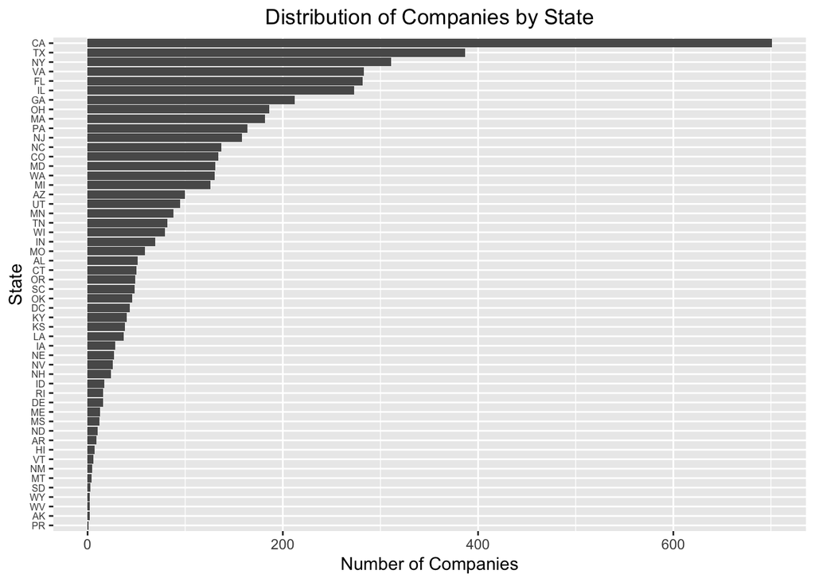

```r
# Answer Question 1 here

state <- inc %>%
  group_by(State) %>%
  summarize(Count = n())

ggplot(data = state, aes(x = reorder(State, Count), y = Count)) +
  geom_bar(stat = "identity") +
  coord_flip() +
  labs(title = "Distribution of Companies by State", x = "State", y = "Number of Companies") +
  theme(axis.text.y = element_text(size = 6)) +
  theme(plot.title = element_text(hjust = 0.5))
```

## Question 2

Let’s dig in on the state with the 3rd most companies in the data set. Imagine you work for the state and are interested in how many people are employed by companies in different industries. Create a plot that shows the average and/or median employment by industry for companies in this state (only use cases with full data, use R’s `complete.cases()` function.) In addition to this, your graph should show how variable the ranges are, and you should deal with outliers.

## Solution:

We first create visualize4 which is a filtered subset of inc containing only use cases with complete data for the state of New York. By sorting this dataset in descending order, we notice that there is a wide variance in Empoyment with companies such as “Sutherland Global Services” and “Coty” employing tens of thousands of employees and on the other end 227 companies with fewer than 100 employees. Instead of eliminating companies that are either small or large (outliers), I instead chose to display median values using the visualize6 dataset in Boxplot # 4.

We could also have chosen to display the untrasnformed count of employees by industry for the state of New York as depicted in the visualize4 dataset. The outliers are clearly evident in the Business Products & Services and in the Consumer Products & Services industries. By eliminating these two industries as a whole, we arrive at a more normalized version of the boxplot that allows a comparison among the remaining industries as depicted in the Boxplot # 2 chart. Note that eliminating outliers in the chart is not the same as eliminating outliers in the underlying dataset. This is evident by comparing Boxplot # 3 (modified chart) with boxplot # 2 (modified data). The modified chart displays all industries and eliminates companies that are outliers rather than eliminate entire industries.

```r
# Answer Question 2 here

library(tidyverse)
library(ggplot2)

# Filter on New York state and include only complete use cases

visualize4 <- inc[complete.cases(inc[, c('State')]),] %>%
  filter(State == "NY", na.rm = TRUE) %>%
  arrange(desc(Employees))

visualize4
```

```
##     Rank                                         Name Growth_Rate   Revenue
## 1   4577                   Sutherland Global Services        0.48 5.976e+08
## 2   4936                                         Coty        0.36 4.600e+09
## 3   4716                                Westcon Group        0.44 3.800e+09
## 4   3899                    Denihan Hospitality Group        0.71 2.808e+08
## 5   4363                                 TransPerfect        0.55 3.413e+08
## 6   1499                         Sterling Infosystems        2.66 2.149e+08
## 7   4465                                     OpenLink        0.52 3.043e+08
## 8   3136                       FSO Onsite Outsourcing        1.05 5.530e+07
## 9   2830                                 ReSource Pro        1.22 2.430e+07
## 10  2995                           Pride Technologies        1.13 2.310e+08
## 11  3387                              Mitchell/Martin        0.92 1.453e+08
## 12  4747                                  TravelClick        0.43 2.571e+08
## 13  2964                                      DataArt        1.14 3.070e+07
## 14  4913                                Jackson Lewis        0.37 3.520e+08
```

[output cut: 609 more lines]

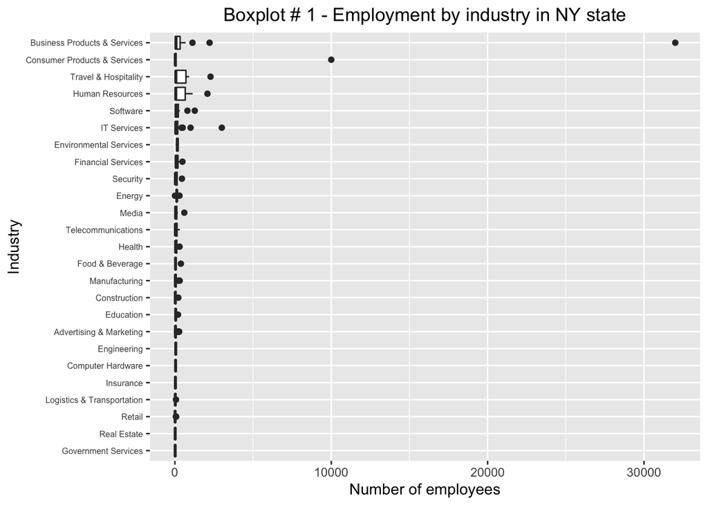

```r
# Plot based on number of employees without eliminating outliers

ggplot(data = visualize4, aes(x = Employees, y = reorder(Industry, Employees))) +
  geom_boxplot() +
  labs(title = "Boxplot # 1 - Employment by industry in NY state", x = "Number of employees", y = "Industry") +
  theme(axis.text.y = element_text(size = 6)) +
  theme(plot.title = element_text(hjust = 0.5))
```

```r
# Eliminate outliers in the underlying data and then plot

visualize5 <- inc[complete.cases(inc[, c('State')]),] %>%
  filter(State == "NY" & Industry != "Consumer Products & Services" & Industry != "Business Products & Services", (na.rm = TRUE)) %>%
  arrange(desc(Employees))

visualize5
```

```
##     Rank                                         Name Growth_Rate   Revenue
## 1   4716                                Westcon Group        0.44 3.800e+09
## 2   3899                    Denihan Hospitality Group        0.71 2.808e+08
## 3   1499                         Sterling Infosystems        2.66 2.149e+08
## 4   4465                                     OpenLink        0.52 3.043e+08
## 5   3136                       FSO Onsite Outsourcing        1.05 5.530e+07
## 6   2995                           Pride Technologies        1.13 2.310e+08
## 7   3387                              Mitchell/Martin        0.92 1.453e+08
## 8   4747                                  TravelClick        0.43 2.571e+08
## 9   2964                                      DataArt        1.14 3.070e+07
## 10  4153                              Everyday Health        0.62 1.464e+08
## 11  4003                         Ovation Travel Group        0.67 5.860e+07
## 12  1640                                     BlueWolf        2.38 9.040e+07
## 13  2971                                     ConServe        1.14 5.270e+07
## 14  4727                               Arrow Security        0.44 1.400e+07
```

[output cut: 523 more lines]

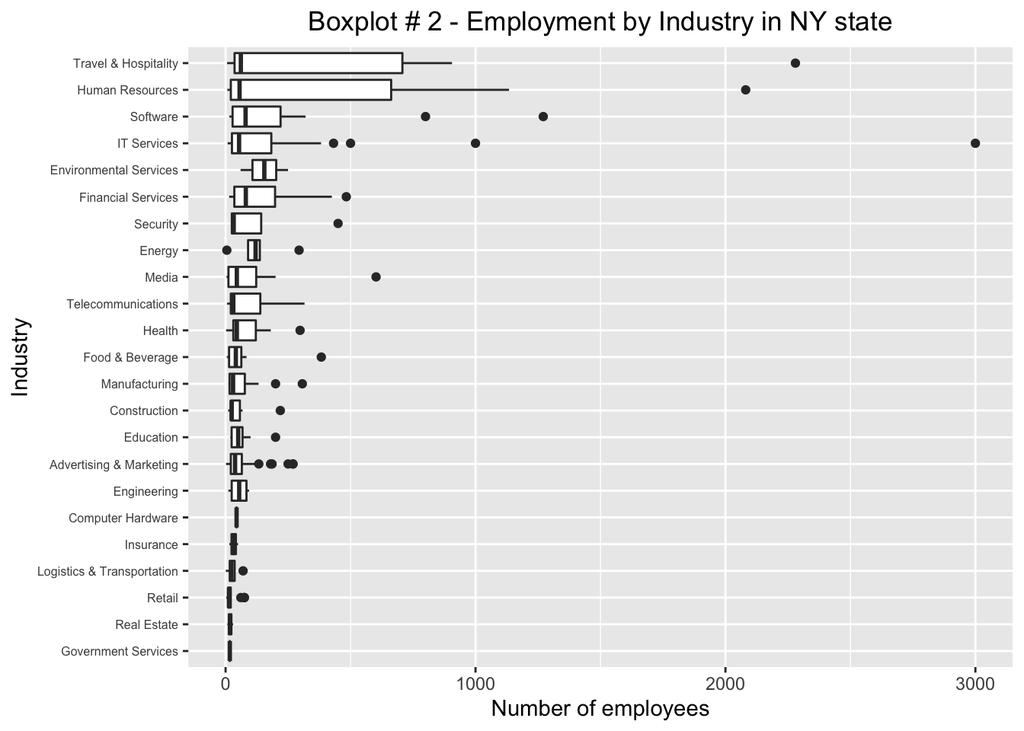

```r
ggplot(data = visualize5, aes(x = Employees, y = reorder(Industry, Employees))) +
  geom_boxplot() +
  labs(title = "Boxplot # 2 - Employment by Industry in NY state", x = "Number of employees", y = "Industry") +
  theme(axis.text.y = element_text(size = 6)) +
  theme(plot.title = element_text(hjust = 0.5))
```

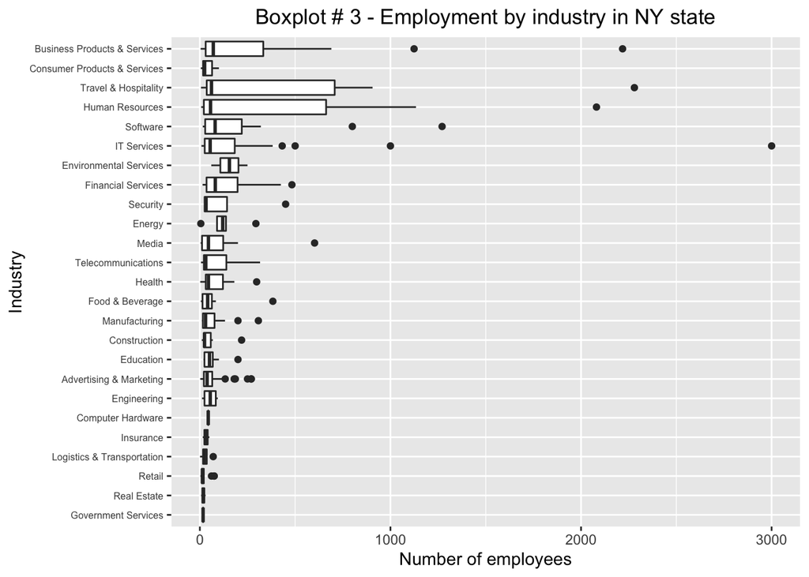

```r
# Eliminate outliers in the plot but not underlying data

ggplot(data = visualize4, aes(x = Employees, y = reorder(Industry, Employees))) +
  geom_boxplot() +
  labs(title = "Boxplot # 3 - Employment by industry in NY state", x = "Number of employees", y = "Industry") +
  coord_cartesian(xlim = c(0, 3000)) +
  theme(axis.text.y = element_text(size = 6)) +
  theme(plot.title = element_text(hjust = 0.5))
```

```r
# Calculate mean, median and standard deviation of employees

visualize6 <- visualize4 %>%
  group_by(Industry) %>%
  summarise(mean_Employees = mean(Employees), median_Employees = median(Employees), sd_Employees = sd(Employees)) %>%
  arrange(desc(median_Employees))

visualize6
```

```
## # A tibble: 25 × 4
##    Industry                     mean_Employees median_Employees sd_Employees
##    <chr>                                 <dbl>            <dbl>        <dbl>
##  1 Environmental Services                155              155          134.
##  2 Energy                                129.             120          105.
##  3 Financial Services                    144.              81          152.
##  4 Software                              246.              80          375.
##  5 Business Products & Services         1492.              70.5       6241.
##  6 Travel & Hospitality                  548.              61          835.
##  7 Human Resources                       438.              56          681.
##  8 Engineering                            53.5             54.5         39.8
##  9 IT Services                           204.              54          473.
## 10 Education                              59.9             50.5         48.6
## # … with 15 more rows
```

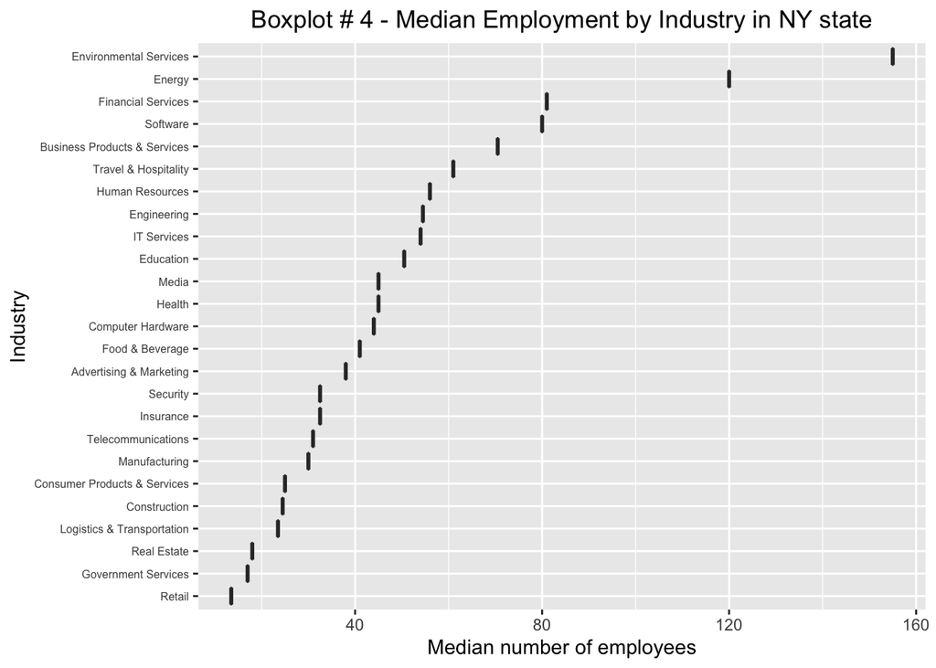

```r
# Plot median number of employees

ggplot(data = visualize6, aes(x = median_Employees, y = reorder(Industry, median_Employees))) +
  geom_boxplot() +
  labs(title = "Boxplot # 4 - Median Employment by Industry in NY state", x = "Median number of employees", y = "Industry") +
  theme(axis.text.y = element_text(size = 6)) +
  theme(plot.title = element_text(hjust = 0.5))
```

## Question 3

Now imagine you work for an investor and want to see which industries generate the most revenue per employee. Create a chart that makes this information clear. Once again, the distribution per industry should be shown.

## Solution:

It is clear from the chart that the Computer Hardware industry generates the most revenue per employee while the Human Resources industry generates the least revenue per employee.

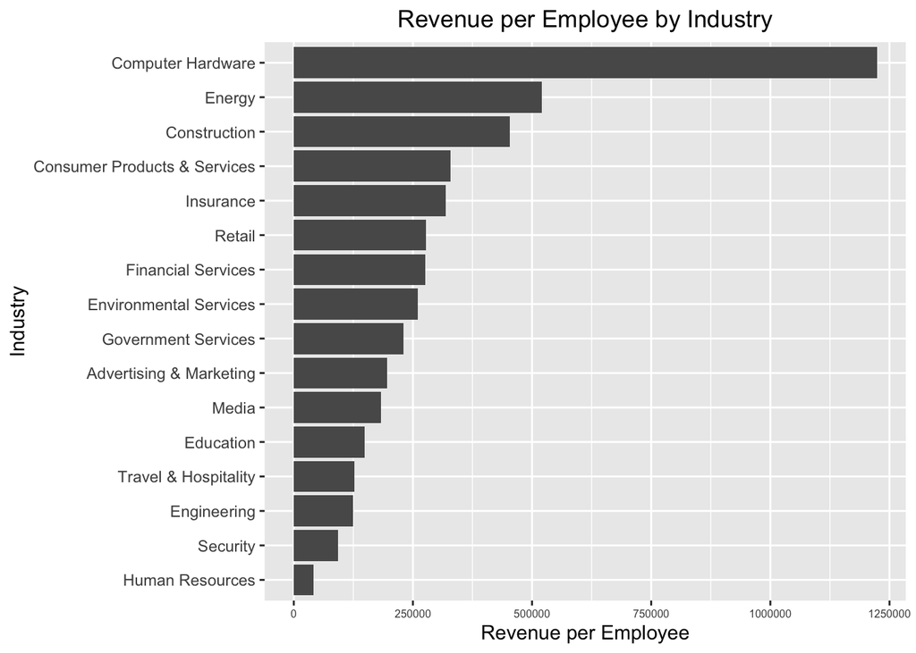

```r
# Answer Question 3 here

revenue <- inc %>%
  group_by(Industry) %>%
  summarize(TotalRev = sum(Revenue), TotalEmp = sum(Employees), RevPerEmp = TotalRev/TotalEmp) %>%
  arrange(desc(RevPerEmp)) %>%
  na.omit()

ggplot(data = revenue, aes(x = reorder(Industry, RevPerEmp), y = RevPerEmp)) +
  geom_bar(stat = "identity") +
  labs(title = "Revenue per Employee by Industry", x = "Industry", y = "Revenue per Employee") +
  theme(plot.title = element_text(hjust = 0.5)) +
  theme(axis.text.x = element_text(size = 6)) +
  coord_flip()
```